[figure not shown]

**UNIVERSIDAD POLITÉCNICA ESTATAL DEL CARCHI**  
**MAESTRIA EN ESTADISTICA APLICADA**  
**MÉTODOS MULTIVARIADOS**

[figure not shown]

**ENSAYO FINAL**

**ANÁLISIS DEL RENDIMIENTO ACADÉMICO DE LA EVALUACIÓN SER BACHILLER EN EL PERIODO 2019 – 2020 (REGIÓN COSTA)**

**DOCENTE**

**LIVINO MANUEL ARMIJOS TORO**

**INTEGRANTES**

**MOSCOSO MORENO JAIRO DAVID**

**MOSCOSO MORENO NATHALY KASSANDRA**

**FECHA**

**11/06/2023**

**INTRODUCCIÓN**

La Evaluación Ser Bachiller es un examen que se realiza en Ecuador y tiene como objetivo evaluar los conocimientos y habilidades adquiridas por los estudiantes al finalizar su educación secundaria. La evaluación abarca diferentes áreas del conocimiento, como matemáticas, lenguaje y comunicación, ciencias naturales, ciencias sociales, y aptitudes abstractas.

Es importante destacar que el rendimiento académico en la Evaluación Ser Bachiller es solo una medida de evaluación y no debe considerarse como el único factor para evaluar la calidad de la educación. Otros aspectos, como el entorno educativo, los recursos disponibles y las oportunidades de aprendizaje, también pueden influir en el rendimiento académico de los estudiantes.

Para obtener información actualizada y análisis específicos sobre el rendimiento académico en la Evaluación Ser Bachiller, te recomendaría consultar fuentes oficiales del Ministerio de Educación de Ecuador o instituciones educativas pertinentes que puedan proporcionar los datos más recientes y análisis detallados.

**PROBLEMA**

El análisis de la Evaluación Ser Bachiller se realiza para abordar diferentes problemas y situaciones relacionadas con el rendimiento académico. Esto incluye la identificación y corrección del bajo rendimiento generalizado, la reducción de las brechas de rendimiento entre grupos de estudiantes, la evaluación de políticas y programas educativos implementados, el seguimiento de cambios en el rendimiento a lo largo del tiempo y la validación de la calidad educativa en general.

Estos análisis proporcionan información valiosa para tomar decisiones y mejorar la calidad de la educación, identificando causas subyacentes, diseñando estrategias de intervención específicas y promoviendo la equidad educativa.

**OBJETIVOS**

1. Evaluar el rendimiento académico de los estudiantes: El objetivo es medir y evaluar los conocimientos y habilidades adquiridos por los estudiantes al finalizar la educación secundaria, identificando fortalezas y debilidades.
2. Identificar áreas de mejora en el currículo y la enseñanza: El análisis de los resultados permite identificar las áreas del currículo en las que los estudiantes tienen dificultades, lo que ayuda a ajustar el plan de estudios y las estrategias de enseñanza para mejorar la calidad educativa.
3. Realizar comparaciones y seguimiento a lo largo del tiempo: Se compara el rendimiento estudiantil de un año a otro para identificar tendencias y evaluar si ha habido mejoras o declives en el rendimiento académico, lo que ayuda a orientar las políticas y decisiones educativas.
4. Establecer estándares y criterios de calidad: Los resultados de la evaluación se utilizan para establecer niveles de rendimiento esperados y definir criterios de calidad en la educación secundaria, contribuyendo a mejorar la calidad educativa en general.
5. Orientar la toma de decisiones educativas: Los resultados del análisis brindan información útil para tomar decisiones a nivel individual, institucional y gubernamental, como identificar áreas de intervención prioritarias, asignar recursos de manera efectiva y diseñar estrategias de mejora educativa.

**MARCO TEÓTICO**

**PRUEBAS DE INGRESO A LA UNIVERSIDAD**

Las pruebas de ingreso a la universidad son herramientas clave para evaluar las habilidades y conocimientos de los estudiantes que desean acceder a la educación superior. Estas pruebas desempeñan un papel fundamental en el proceso de selección de candidatos y en la garantía de la calidad de los estudiantes que ingresan a las instituciones universitarias. En este marco teórico, se explorarán los aspectos esenciales relacionados con el diseño, implementación y efectividad de las pruebas de ingreso a la universidad, basándonos en investigaciones científicas en el campo.

**Diseño de las pruebas de ingreso a la universidad**

El diseño de las pruebas de ingreso a la universidad requiere una cuidadosa planificación y consideración de diversos elementos. Según López et al. (2019), es esencial definir los objetivos de evaluación, establecer los criterios de medición y seleccionar los contenidos relevantes para evaluar las habilidades y conocimientos necesarios para el ingreso a la educación superior. Además, se deben considerar los aspectos de equidad, como la inclusión de ítems libres de sesgos y la adaptación a las características de la población evaluada.

**Implementación de las pruebas de ingreso a la universidad**

La implementación de las pruebas de ingreso a la universidad implica la aplicación de los instrumentos de evaluación en un entorno controlado. Según Castro et al. (2018), es necesario asegurar las condiciones adecuadas para la administración de las pruebas, como la estandarización de los procedimientos, la capacitación de los aplicadores y el establecimiento de medidas de seguridad para prevenir posibles fraudes. Además, se deben considerar aspectos logísticos, como la gestión eficiente de los recursos y la comunicación clara de las instrucciones a los evaluados.

**Efectividad y calidad de las pruebas de ingreso a la universidad**

La efectividad de las pruebas de ingreso a la universidad se refiere a la capacidad de estas pruebas para predecir el éxito académico de los estudiantes en la educación superior. Según Rodríguez et al. (2017), es importante evaluar la validez de las pruebas en relación con los resultados académicos posteriores, así como analizar la consistencia interna y confiabilidad de los instrumentos de evaluación. Además, se deben considerar estrategias de mejora continua para mantener la calidad de las pruebas y asegurar su validez y confiabilidad a lo largo del tiempo.

Las pruebas de ingreso a la universidad desempeñan un papel crucial en la promoción de la equidad, la selección justa, la predicción del rendimiento académico y la mejora de la calidad educativa. Estas pruebas proporcionan una medida objetiva de las habilidades y conocimientos de los estudiantes, permitiendo a las instituciones universitarias seleccionar a aquellos que tienen más probabilidades de tener éxito en sus estudios superiores. Además, estas pruebas también ofrecen retroalimentación importante para mejorar el sistema educativo en general.

**DISEÑO E IMPLEMENTACIÓN DE PRUEBAS DE INGRESO**

El diseño y la implementación de pruebas de ingreso a la universidad son procesos fundamentales para evaluar las habilidades y conocimientos de los estudiantes que buscan acceder a la educación superior. Estas pruebas desempeñan un papel crucial en la selección de los candidatos más aptos y garantizan la calidad de los estudiantes que ingresan a las instituciones universitarias. En este marco teórico, se explorarán los elementos clave del diseño y la implementación de estas pruebas, respaldados por la investigación científica en el campo.

**Validación y confiabilidad de las pruebas**

El diseño de las pruebas de ingreso a la universidad requiere una sólida validación y confiabilidad para garantizar la precisión de los resultados. Según Hernández Pina et al. (2015), la validación de las pruebas implica acumular evidencia empírica que respalde su uso y la interpretación de los resultados, estableciendo su relación con criterios externos, como el rendimiento académico posterior. Asimismo, es esencial realizar análisis de confiabilidad para evaluar la consistencia interna y la estabilidad de las pruebas a lo largo del tiempo (Molina-Azorín, 2017)

**Diseño de ítems y formatos**

El diseño de los ítems y la selección de los formatos de las pruebas de ingreso a la universidad son aspectos cruciales para evaluar las habilidades y conocimientos de manera efectiva. Según Fidalgo-Blanco et al. (2016), la inclusión de diferentes tipos de ítems, como preguntas de opción múltiple, preguntas abiertas y problemas prácticos, permite evaluar diversas dimensiones del rendimiento académico y promover la transferencia de conocimientos. Además, el uso de formatos innovadores, como las pruebas basadas en competencias, puede mejorar la autenticidad y la relevancia de las evaluaciones (Torres, 2013).

**Proceso de implementación y mejora continua**

La implementación de pruebas de ingreso a la universidad implica un proceso riguroso y continuo, que requiere análisis y mejora constantes. Según Segovia, Valenzuela, y López (2018), es fundamental realizar un análisis exhaustivo de los resultados obtenidos y evaluar la efectividad de las pruebas en la selección de candidatos y en la predicción del rendimiento académico. Esto permite identificar áreas de mejora, ajustar los criterios de evaluación y asegurar la validez y confiabilidad de las pruebas a lo largo del tiempo.

El diseño e implementación de pruebas de ingreso a la universidad requiere una validación sólida, la consideración de diversos ítems y formatos, así como un análisis y mejora continuos del proceso. Estos elementos contribuyen a la selección de los candidatos más aptos y a garantizar la calidad de los estudiantes que ingresan a las instituciones universitarias.

**BASE DE DATOS**

La Base de datos utilizada es la que se encuentra publicada por el “Instituto Nacional de Evaluación Educativa” y corresponde a los resultados obtenidos en el periodo 2019-2020, en la región costa.

Se seleccionó esta base ya que es la última de carácter público que se encuentra dentro del sistema, con el objetivo de tener la información actual. Consta de aproximadamente 270.000 datos (base pura, sin procesar). El formato obtenido fue .sav (formato propio de SPSS), con el que se armó un dataframe inicial.

Para fines prácticos y por peso de la BBDD se adjunta el enlace donde se encuentra subida la misma:

https://drive.google.com/file/d/1-d3igsrix39YQOhIp6QCbfyOJ6yRjh1W/view?usp=sharing

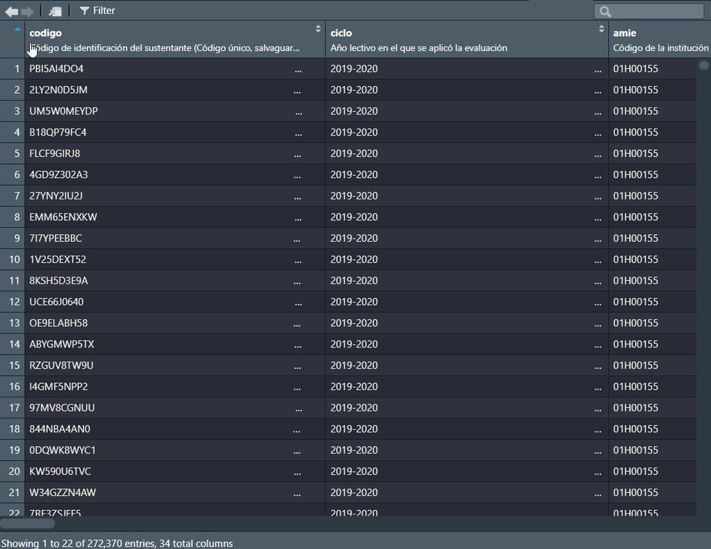

Procesamiento de datos 1.1 Lectura de datos

```r
library(rstudioapi)
setwd(dirname(getActiveDocumentContext()$path))
library(readxl)
library(foreign)
data_inicial <- read.spss("TRABAJO-FINAL-METODOS-MULTIVARIANTES.sav", to.data.frame=TRUE)
```

```
## re-encoding from CP1252
```

1.2 Llamar paquetes

```r
library(dplyr)
```

```r
library(ggplot2)
library(ggpubr)
library(MVN)
library(biotools)
```

2 Preparación de datos 2.1 Filtrar datos

Una vez creada la data frame “datos” se ha filtrado con la función “filter” únicamente a los estudiantes en estado EVALUADO, por tando la nueva data frame “datos_filtrados” contendrá las filas que cumplen las condiciones del filtro.

```r
datos_filtrados <- filter(data_inicial, estado == "Evaluado")
```

3. Variables a utilizar Mediante la funcion “attach” se separa la dara y se obtiene el dara frame “data_procesada” misma que nos filtra en columnas las variables: IMAT= Nota obtenida en el campo de Matemática ILYL= Nota obtenida en el campo de Lengua y Literatura ICN= Nota obtenida en el campo de Ciencias Naturales IES= Nota obtenida en el campo de Ciencias Sociales TP_SOST= Tipo de sostenimiento de la institución educativa

En esta última variable se utiliza la funcion “factor” y se asgina las etiquetas: -Particular -Municipal -Fiscomisional -Fiscal

```r
#attach(datos_filtrados)
data_procesada <- data.frame(imat = datos_filtrados$imat, ilyl = datos_filtrados$ilyl, icn = datos_filtrados$icn, ies = datos_filtrados$ies, tp_sost = datos_filtrados$tp_sost)
```

3.1 Eliminacion de NA

```r
sum(is.na(data_procesada))
```

```
## [1] 452652
```

```r
data_procesada <- na.omit(data_procesada)
```

Mediante la utilización del codigo se puede determinar que existen un numero de 452652 datos nulos, por lo tanto se procede a eliminar de la base.

```r
data_procesada$Id= 1:169580
N<-length(data_procesada$Id)
n= 10000
set.seed(123)
ind1<-sample(1:N,n,replace = F)
ind1= sort(ind1)
data_muestra= data_procesada[ind1,]
attach(data_muestra)
```

4 Estadistica 4.1 Descripción de variables Las características estadísticas de todas las variables presentes en el conjunto de datos, tanto numéricas como de factor.

Para las variables numéricas, se proporcionan el valor mínimo, el primer cuartil, la mediana, la media, el tercer cuartil y el valor máximo.

```r
summary(data_muestra)
```

```
##       imat             ilyl             icn              ies
##  Min.   : 4.380   Min.   : 4.000   Min.   : 4.000   Min.   : 4.000
##  1st Qu.: 7.000   1st Qu.: 6.670   1st Qu.: 7.110   1st Qu.: 7.150
##  Median : 7.560   Median : 7.350   Median : 7.560   Median : 7.450
##  Mean   : 7.665   Mean   : 7.423   Mean   : 7.691   Mean   : 7.641
##  3rd Qu.: 8.310   3rd Qu.: 8.060   3rd Qu.: 8.110   3rd Qu.: 8.200
##  Max.   :10.000   Max.   :10.000   Max.   :10.000   Max.   :10.000
##           tp_sost           Id
##  Particular   :1828   Min.   :    18
##  Municipal    :  26   1st Qu.: 42682
##  Fiscomisional: 714   Median : 85659
##  Fiscal       :7432   Mean   : 85167
##                       3rd Qu.:128182
##                       Max.   :169568
```

```r
tapply(imat,list(tp_sost),mean)
```

```
##    Particular     Municipal Fiscomisional        Fiscal
##      8.108332      8.004231      7.738137      7.548240
```

Con los resultado obtenidos se puede determinar que las notas de IMAT (Nota obtenida en el campo de Matemática) es mas alta en las insticuciones de origen particular con 8.108332, seguido de municipal con 8.004231 , fiscomisional con 7.738137 y por ultimo fiscal con 7.548240.

```r
tapply(ilyl,list(tp_sost),mean)
```

```
##    Particular     Municipal Fiscomisional        Fiscal
##      7.922659      7.930000      7.504958      7.289818
```

```r
tapply(icn,list(tp_sost),mean)
```

```
##    Particular     Municipal Fiscomisional        Fiscal
##      8.044261      7.871923      7.753445      7.598131
```

```r
tapply(ies,list(tp_sost),mean)
```

```
##    Particular     Municipal Fiscomisional        Fiscal
##      8.040345      7.848077      7.686204      7.537435
```

5 Análisis gráfico

```r
plot1 <- ggplot(data=data_muestra, aes(tp_sost,imat)) + geom_boxplot() +
  ggtitle("Rendimiento INEVAL - Matemáticas") + xlab("Sostenimiento") + ylab("Notas")

plot2 <- ggplot(data=data_muestra, aes(tp_sost,ilyl)) + geom_boxplot() +
  ggtitle("Rendimiento INEVAL - Lenguaje") + xlab("Sostenimiento") + ylab("Notas")

plot3 <- ggplot(data=data_muestra, aes(tp_sost,icn)) + geom_boxplot() +
  ggtitle("Rendimiento INEVAL - Ciencias") + xlab("Sostenimiento") + ylab("Notas")

plot4 <- ggplot(data=data_muestra, aes(tp_sost,ies)) + geom_boxplot() +
  ggtitle("Rendimiento INEVAL - Sociales") + xlab("Sostenimiento") + ylab("Notas")
```

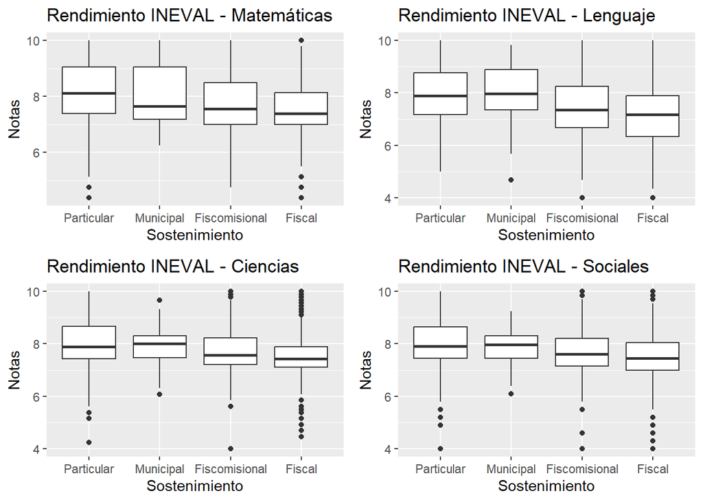

```r
ggarrange(plot1, plot2,plot3, plot4)
```

Mediante los gráficos se puede observar datos atipicos, las medianas varian ligeramente, no obdtamte la mayoria de datos se encuentran entre un rango de 7-9 respectivamente.

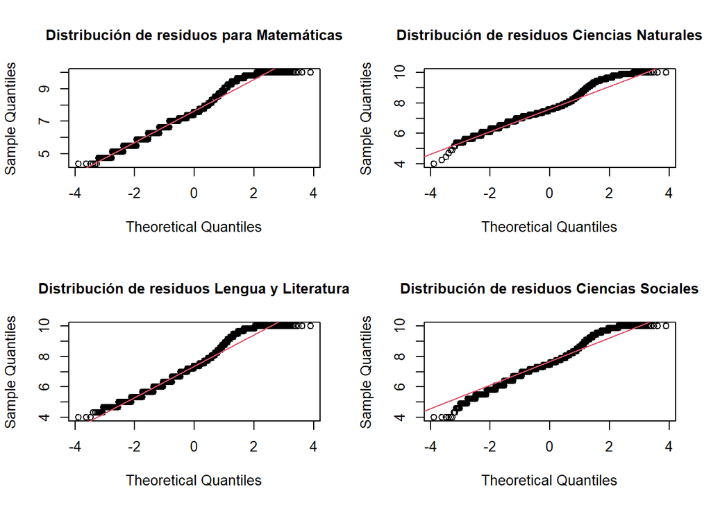

```r
par(mfcol = c(2, 2))
r1<-qqnorm(data_muestra$imat,
           main = "Distribución de residuos para Matemáticas", cex.main=1)
qqline(data_muestra$imat, col = 2)

r2<-qqnorm(data_muestra$ilyl,
           main = "Distribución de residuos Lengua y Literatura", cex.main=1)
qqline(data_muestra$ilyl, col = 2)

r3<-qqnorm(data_muestra$icn,
           main = "Distribución de residuos Ciencias Naturales", cex.main=1)
qqline(data_muestra$icn, col = 2)

r4<-qqnorm(data_muestra$ies,
           main = "Distribución de residuos Ciencias Sociales", cex.main=1)
qqline(data_muestra$ies, col = 2)
```

Se procede a realizar pruebas de normalidad para evidenciar si existe normalidad en los datos.

5.1 Correlacion

```r
library(PerformanceAnalytics)
```

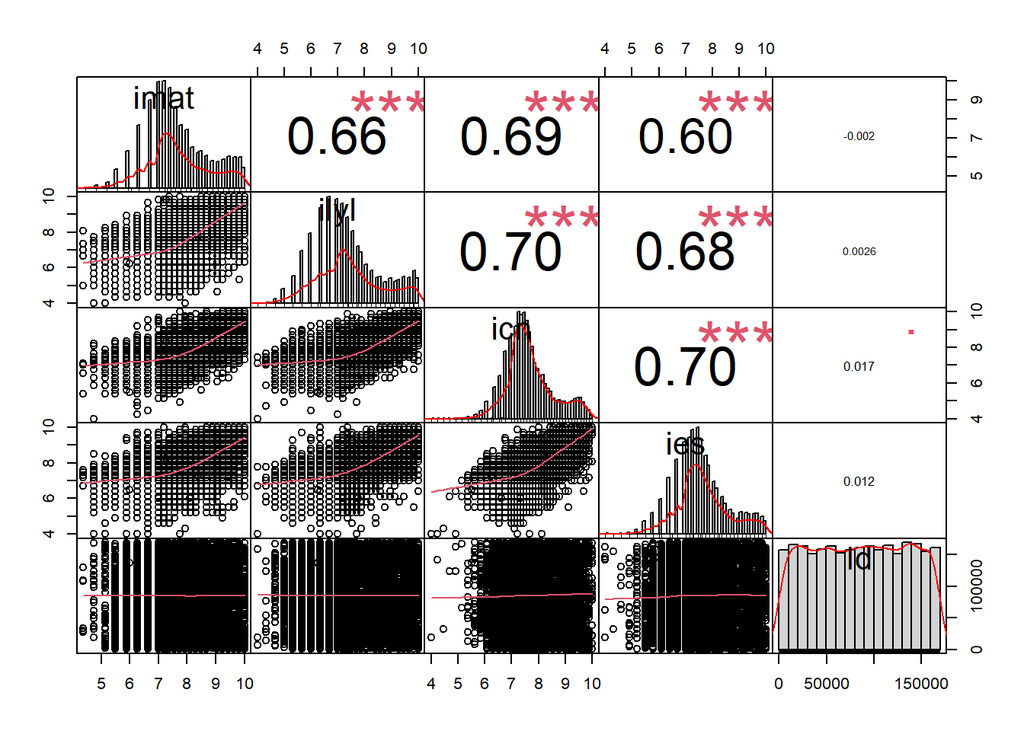

```r
chart.Correlation(data_muestra[, -5], histogram = TRUE, method = "pearson", pch = 0.5)
```

Con el siuguiente analisis se puede observar:

```r
MN=manova(cbind(data_muestra$imat,data_muestra$ilyl,data_muestra$icn,data_muestra$ies) ~ data_muestra$tp_sost)
MN
```

```
## Call:
##    manova(cbind(data_muestra$imat, data_muestra$ilyl, data_muestra$icn,
##     data_muestra$ies) ~ data_muestra$tp_sost)
##
## Terms:
##                 data_muestra$tp_sost Residuals
## resp 1                        467.41  11599.37
## resp 2                       599.677 14049.683
## resp 3                       295.854  6954.540
## resp 4                       373.809  9004.546
## Deg. of Freedom                    3      9996
##
## Residual standard errors: 1.077219 1.185551 0.8341057 0.9491127
## Estimated effects may be unbalanced
```

```r
summary(MN,test="Wilks")
```

```
##                        Df   Wilks approx F num Df den Df    Pr(>F)
## data_muestra$tp_sost    3 0.94643   46.331     12  26439 < 2.2e-16 ***
## Residuals            9996
## ---
## Signif. codes:  0 '***' 0.001 '**' 0.01 '*' 0.05 '.' 0.1 ' ' 1
```

Existen diferencias significativas en los resultados de las evaluaciones de las respectivas asignaturas, según el tipo de sostenimiento.

6 Normalidad multivariada

```r
library(MVN)
par(mfcol = c(1, 1))
outliers <- mvn(data = data_muestra[,-5], mvnTest = "hz", multivariateOutlierMethod = "quan")
```

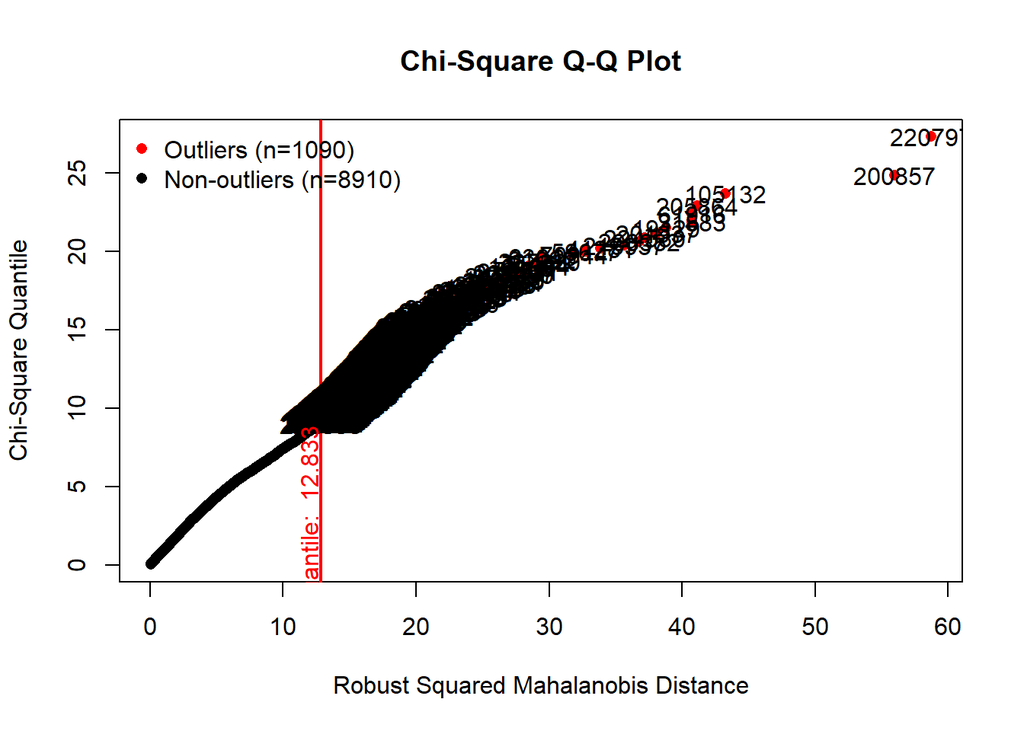

Mediante la representación gráfica se puede determinar que de los 10000 datos, 1090 son atípicos.

6.1 Prueba de normalidad multivariada

```r
result <- mvn(data = data_muestra[,-5], mvnTest = "dh", desc = TRUE)
result$multivariateNormality
```

```
##             Test        E df p value MVN
## 1 Doornik-Hansen 251638.1 10       0  NO
```

```r
hz_test <- mvn(data = data_muestra[,-5], mvnTest = "hz")
hz_test$multivariateNormality
```

```
##            Test       HZ p value MVN
## 1 Henze-Zirkler 10.48419       0  NO
```

Mediante la aplicacion de las pruebas de Doornik-Hansen y Henze-Zirkler se comprueba que hay suficiente evidencia estadística para afirmar la no normalidad de las variables.

6.2 Igualdad de matrices de varianzas y covarianzas

```r
boxM(as.matrix(data_muestra[,1:4]),as.matrix(data_muestra$tp_sost))
```

```
##
##  Box's M-test for Homogeneity of Covariance Matrices
##
## data:  as.matrix(data_muestra[, 1:4])
## Chi-Sq (approx.) = 186.32, df = 30, p-value < 2.2e-16
```

Con un p-valor altamente significativa, es posible asumir que las matrices de varianza y covarianza por cada uno de los sostenimientos no son similares

6.3 COMPARACIÓN DE LAS MATRICES DE LOS DATOS PARA VERIFICAR IGUALDAD 6.3.1 Datos por cada sostenimiento

```r
data.part <- filter(data_muestra, tp_sost == "Particular")
data.munic <- filter(data_muestra, tp_sost == "Municipal")
data.fisco <- filter(data_muestra, tp_sost == "Fiscomisional")
data.fiscal <- filter(data_muestra, tp_sost == "Fiscal")
```

6.3.2 Vector de medias

```r
vec.mediaspart=apply(data.part[,1:4],2,mean);vec.mediaspart
```

```
##     imat     ilyl      icn      ies
## 8.108332 7.922659 8.044261 8.040345
```

```r
vec.mediasmunic=apply(data.munic[,1:4],2,mean);vec.mediasmunic
```

```
##     imat     ilyl      icn      ies
## 8.004231 7.930000 7.871923 7.848077
```

```r
vec.mediasfisco=apply(data.fisco[,1:4],2,mean);vec.mediasfisco
```

```
##     imat     ilyl      icn      ies
## 7.738137 7.504958 7.753445 7.686204
```

```r
vec.mediasfiscal=apply(data.fiscal[,1:4],2,mean);vec.mediasfiscal
```

```
##     imat     ilyl      icn      ies
## 7.548240 7.289818 7.598131 7.537435
```

6.3.3 Matrices de covarianza

```r
varpart=var(data.part[,1:4]); varpart
```

```
##           imat      ilyl       icn       ies
## imat 1.2549621 0.9484595 0.7703118 0.7176459
## ilyl 0.9484595 1.3754725 0.8028524 0.8279663
## icn  0.7703118 0.8028524 0.8322536 0.6607004
## ies  0.7176459 0.8279663 0.6607004 0.9286848
```

```r
varmunic=var(data.munic[,1:4]); varmunic
```

```
##           imat     ilyl       icn       ies
## imat 1.3459614 1.253520 0.8072835 0.5937485
## ilyl 1.2535200 1.922656 0.8982520 0.7526400
## icn  0.8072835 0.898252 0.8321362 0.4378638
## ies  0.5937485 0.752640 0.4378638 0.7468962
```

```r
varfisco=var(data.fisco[,1:4]); varfisco
```

```
##           imat      ilyl       icn       ies
## imat 1.2450390 0.9051944 0.6473269 0.6745220
## ilyl 0.9051944 1.4594172 0.7143569 0.8545299
## icn  0.6473269 0.7143569 0.7059488 0.5741317
## ies  0.6745220 0.8545299 0.5741317 0.9907246
```

```r
varfiscal=var(data.fiscal[,1:4]); varfiscal
```

```
##           imat      ilyl       icn       ies
## imat 1.1284067 0.7822033 0.5607793 0.5605566
## ilyl 0.7822033 1.4060105 0.6456989 0.7155428
## icn  0.5607793 0.6456989 0.6607277 0.5120009
## ies  0.5605566 0.7155428 0.5120009 0.8858539
```

6.3.4 Parametros de intervalo

```r
vec.mediasTotal=apply(data_muestra[,1:4],2,mean);vec.mediasTotal
```

```
##     imat     ilyl      icn      ies
## 7.665369 7.422527 7.691485 7.640797
```

```r
t1=vec.mediaspart-vec.mediasTotal
t2=vec.mediasmunic-vec.mediasTotal
t3=vec.mediasfisco-vec.mediasTotal
t4=vec.mediasfiscal-vec.mediasTotal
W=(dim(data.part)[1]-1)*varpart + (dim(data.munic)[1]-1)*varmunic + (dim(data.fisco)[1]-1)*varfisco +
  (dim(data.fiscal)[1]-1)*varfiscal; W
```

```
##           imat      ilyl      icn      ies
## imat 11599.368  8222.130 6056.237 5972.413
## ilyl  8222.130 14049.683 6796.792 7457.989
## icn   6056.237  6796.792 6954.540 5432.081
## ies   5972.413  7457.989 5432.081 9004.546
```

7 INFERENCIA ENTRE PARES DE MEDIAS DE LAS MATRICES 7.1 Intervalo de confianza entre particular y municipal a IMAT

```r
t.part_munic.imat=t1[1]-t2[1]
p.part_munic.imat=sqrt(((1/dim(data.part)[1])+(1/dim(data.munic)[1]))*(W[1,1]/(dim(data_muestra)[1]-4)))
(limsup.part_munic.imat=t.part_munic.imat+p.part_munic.imat)
```

```
##      imat
## 0.3168579
```

```r
(liminf.part_munic.imat=t.part_munic.imat-p.part_munic.imat)
```

```
##       imat
## -0.1086564
```

7.2 Intervalo de confianza entre particular y fiscomisional a IMAT

```r
t.part_fisco.imat=t1[1]-t3[1]
p.part_fisco.imat=sqrt(((1/dim(data.part)[1])+(1/dim(data.fisco)[1]))*(W[1,1]/(dim(data_muestra)[1]-4)))
(limsup.part_fisco.imat=t.part_fisco.imat+p.part_fisco.imat)
```

```
##      imat
## 0.4177338
```

```r
(liminf.part_fisco.imat=t.part_fisco.imat-p.part_fisco.imat)
```

```
##      imat
## 0.3226548
```

7.3 Intervalo de confianza entre particular y fiscal a IMAT

```r
t.part_fiscal.imat=t1[1]-t4[1]
p.part_fiscal.imat=sqrt(((1/dim(data.part)[1])+(1/dim(data.fiscal)[1]))*(W[1,1]/(dim(data_muestra)[1]-4)))
(limsup.part_fiscal.imat=t.part_fiscal.imat+p.part_fiscal.imat)
```

```
##      imat
## 0.5882149
```

```r
(liminf.part_fiscal.imat=t.part_fiscal.imat-p.part_fiscal.imat)
```

```
##     imat
## 0.531968
```

7.4 Intervalo de confianza entre municipal y fiscomisional a IMAT

```r
t.munic_fisco.imat=t2[1]-t3[1]
p.munic_fisco.imat=sqrt(((1/dim(data.munic)[1])+(1/dim(data.fiscal)[1]))*(W[1,1]/(dim(data_muestra)[1]-4)))
(limsup.munic_fisco.imat=t.munic_fisco.imat+p.munic_fisco.imat)
```

```
##      imat
## 0.4777228
```

```r
(liminf.munic_fisco.imat=t.munic_fisco.imat-p.munic_fisco.imat)
```

```
##       imat
## 0.05446426
```

7.5 Intervalo de confianza entre municipal y fiscal a IMAT

```r
t.munic_fiscal.imat=t2[1]-t4[1]
p.munic_fiscal.imat=sqrt(((1/dim(data.munic)[1])+(1/dim(data.fiscal)[1]))*(W[1,1]/(dim(data_muestra)[1]-4)))
(limsup.munic_fiscal.imat=t.munic_fiscal.imat+p.munic_fiscal.imat)
```

```
##    imat
## 0.66762
```

```r
(liminf.munic_fiscal.imat=t.munic_fiscal.imat-p.munic_fiscal.imat)
```

```
##      imat
## 0.2443615
```

7.6 Intervalo de confianza entre fiscomisional y fiscal a IMAT

```r
t.fisco_fiscal.imat=t3[1]-t4[1]
p.fisco_fiscal.imat=sqrt(((1/dim(data.fisco)[1])+(1/dim(data.fiscal)[1]))*(W[1,1]/(dim(data_muestra)[1]-4)))
(limsup.fisco_fiscal.imat=t.part_fisco.imat+p.part_fiscal.imat)
```

```
##      imat
## 0.3983177
```

```r
(liminf.fisco_fiscal.imat=t.part_fisco.imat-p.part_fiscal.imat)
```

```
##      imat
## 0.3420708
```

7.7 Intervalo de confianza entre particular y municipal a ILYL

```r
t.part_munic.ilyl=t1[2]-t2[2]
p.part_munic.ilyl=sqrt(((1/dim(data.part)[1])+(1/dim(data.munic)[1]))*(W[2,2]/(dim(data_muestra)[1]-4)))
(limsup.part_munic.ilyl=t.part_munic.ilyl+p.part_munic.ilyl)
```

```
##      ilyl
## 0.2268119
```

```r
(liminf.part_munic.ilyl=t.part_munic.ilyl-p.part_munic.ilyl)
```

```
##       ilyl
## -0.2414946
```

7.8 Intervalo de confianza entre particular y fiscomisional a ILYL

```r
t.part_fisco.ilyl=t1[2]-t3[2]
p.part_fisco.ilyl=sqrt(((1/dim(data.part)[1])+(1/dim(data.fisco)[1]))*(W[2,2]/(dim(data_muestra)[1]-4)))
(limsup.part_fisco.ilyl=t.part_fisco.ilyl+p.part_fisco.ilyl)
```

```
##     ilyl
## 0.470021
```

```r
(liminf.part_fisco.ilyl=t.part_fisco.ilyl-p.part_fisco.ilyl)
```

```
##      ilyl
## 0.3653803
```

7.9 Intervalo de confianza entre particular y fiscal a ILYL

```r
t.part_fiscal.ilyl=t1[2]-t4[2]
p.part_fiscal.ilyl=sqrt(((1/dim(data.part)[1])+(1/dim(data.fiscal)[1]))*(W[2,2]/(dim(data_muestra)[1]-4)))
(limsup.part_fiscal.ilyl=t.part_fiscal.ilyl+p.part_fiscal.ilyl)
```

```
##     ilyl
## 0.663792
```

```r
(liminf.part_fiscal.ilyl=t.part_fiscal.ilyl-p.part_fiscal.ilyl)
```

```
##      ilyl
## 0.6018886
```

7.10 Intervalo de confianza entre municipal y fiscomisional a ILYL

```r
t.munic_fisco.ilyl=t2[2]-t3[2]
p.munic_fisco.ilyl=sqrt(((1/dim(data.munic)[1])+(1/dim(data.fiscal)[1]))*(W[2,2]/(dim(data_muestra)[1]-4)))
(limsup.munic_fisco.ilyl=t.munic_fisco.ilyl+p.munic_fisco.ilyl)
```

```
##     ilyl
## 0.657954
```

```r
(liminf.munic_fisco.ilyl=t.munic_fisco.ilyl-p.munic_fisco.ilyl)
```

```
##    ilyl
## 0.19213
```

7.11 Intervalo de confianza entre municipal y fiscal a ILYL

```r
t.munic_fiscal.ilyl=t2[2]-t4[2]
p.munic_fiscal.ilyl=sqrt(((1/dim(data.munic)[1])+(1/dim(data.fiscal)[1]))*(W[2,2]/(dim(data_muestra)[1]-4)))
(limsup.munic_fiscal.ilyl=t.munic_fiscal.ilyl+p.munic_fiscal.ilyl)
```

```
##      ilyl
## 0.8730936
```

```r
(liminf.munic_fiscal.ilyl=t.munic_fiscal.ilyl-p.munic_fiscal.ilyl)
```

```
##      ilyl
## 0.4072697
```

7.12 Intervalo de confianza entre fiscomisional y fiscal a ILYL

```r
t.fisco_fiscal.ilyl=t3[2]-t4[2]
p.fisco_fiscal.ilyl=sqrt(((1/dim(data.fisco)[1])+(1/dim(data.fiscal)[1]))*(W[2,2]/(dim(data_muestra)[1]-4)))
(limsup.fisco_fiscal.ilyl=t.part_fisco.ilyl+p.part_fiscal.ilyl)
```

```
##      ilyl
## 0.4486524
```

```r
(liminf.fisco_fiscal.ilyl=t.part_fisco.ilyl-p.part_fiscal.ilyl)
```

```
##      ilyl
## 0.3867489
```

7.13 Intervalo de confianza entre particular y municipal a ICN

```r
t.part_munic.icn=t1[3]-t2[3]
p.part_munic.icn=sqrt(((1/dim(data.part)[1])+(1/dim(data.munic)[1]))*(W[3,3]/(dim(data_muestra)[1]-4)))
(limsup.part_munic.icn=t.part_munic.icn+p.part_munic.icn)
```

```
##       icn
## 0.3370792
```

```r
(liminf.part_munic.icn=t.part_munic.icn-p.part_munic.icn)
```

```
##         icn
## 0.007597612
```

7.14 Intervalo de confianza entre particular y fiscomisional a ICN

```r
t.part_fisco.icn=t1[3]-t3[3]
p.part_fisco.icn=sqrt(((1/dim(data.part)[1])+(1/dim(data.fisco)[1]))*(W[3,3]/(dim(data_muestra)[1]-4)))
(limsup.part_fisco.icn=t.part_fisco.icn+p.part_fisco.icn)
```

```
##       icn
## 0.3276266
```

```r
(liminf.part_fisco.icn=t.part_fisco.icn-p.part_fisco.icn)
```

```
##       icn
## 0.2540056
```

7.15 Intervalo de confianza entre particular y fiscal a ICN

```r
t.part_fiscal.icn=t1[3]-t4[3]
p.part_fiscal.icn=sqrt(((1/dim(data.part)[1])+(1/dim(data.fiscal)[1]))*(W[3,3]/(dim(data_muestra)[1]-4)))
(limsup.part_fiscal.icn=t.part_fiscal.icn+p.part_fiscal.icn)
```

```
##       icn
## 0.4679068
```

```r
(liminf.part_fiscal.icn=t.part_fiscal.icn-p.part_fiscal.icn)
```

```
##       icn
## 0.4243541
```

7.16 Intervalo de confianza entre municipal y fiscomisional a ICN

```r
t.munic_fisco.icn=t2[3]-t3[3]
p.munic_fisco.icn=sqrt(((1/dim(data.munic)[1])+(1/dim(data.fiscal)[1]))*(W[3,3]/(dim(data_muestra)[1]-4)))
(limsup.munic_fisco.icn=t.munic_fisco.icn+p.munic_fisco.icn)
```

```
##       icn
## 0.2823452
```

```r
(liminf.munic_fisco.icn=t.munic_fisco.icn-p.munic_fisco.icn)
```

```
##         icn
## -0.04538977
```

7.17 Intervalo de confianza entre municipal y fiscal a ICN

```r
t.munic_fiscal.icn=t2[3]-t4[3]
p.munic_fiscal.icn=sqrt(((1/dim(data.munic)[1])+(1/dim(data.fiscal)[1]))*(W[3,3]/(dim(data_muestra)[1]-4)))
(limsup.munic_fiscal.icn=t.munic_fiscal.icn+p.munic_fiscal.icn)
```

```
##       icn
## 0.4376595
```

```r
(liminf.munic_fiscal.icn=t.munic_fiscal.icn-p.munic_fiscal.icn)
```

```
##       icn
## 0.1099246
```

7.18 Intervalo de confianza entre fiscomisional y fiscal a ICN

```r
t.fisco_fiscal.icn=t3[3]-t4[3]
p.fisco_fiscal.icn=sqrt(((1/dim(data.fisco)[1])+(1/dim(data.fiscal)[1]))*(W[3,3]/(dim(data_muestra)[1]-4)))
(limsup.fisco_fiscal.icn=t.part_fisco.icn+p.part_fiscal.icn)
```

```
##       icn
## 0.3125925
```

```r
(liminf.fisco_fiscal.icn=t.part_fisco.icn-p.part_fiscal.icn)
```

```
##       icn
## 0.2690397
```

7.19 Intervalo de confianza entre particular y municipal a IES

```r
t.part_munic.ies=t1[4]-t2[4]
p.part_munic.ies=sqrt(((1/dim(data.part)[1])+(1/dim(data.munic)[1]))*(W[4,4]/(dim(data_muestra)[1]-4)))
(limsup.part_munic.ies=t.part_munic.ies+p.part_munic.ies)
```

```
##       ies
## 0.3797231
```

```r
(liminf.part_munic.ies=t.part_munic.ies-p.part_munic.ies)
```

```
##         ies
## 0.004812345
```

7.20 Intervalo de confianza entre particular y fiscomisional a IES

```r
t.part_fisco.ies=t1[4]-t3[4]
p.part_fisco.ies=sqrt(((1/dim(data.part)[1])+(1/dim(data.fisco)[1]))*(W[4,4]/(dim(data_muestra)[1]-4)))
(limsup.part_fisco.ies=t.part_fisco.ies+p.part_fisco.ies)
```

```
##       ies
## 0.3960261
```

```r
(liminf.part_fisco.ies=t.part_fisco.ies-p.part_fisco.ies)
```

```
##       ies
## 0.3122542
```

7.21 Intervalo de confianza entre particular y fiscal a IES

```r
t.part_fiscal.ies=t1[4]-t4[4]
p.part_fiscal.ies=sqrt(((1/dim(data.part)[1])+(1/dim(data.fiscal)[1]))*(W[4,4]/(dim(data_muestra)[1]-4)))
(limsup.part_fiscal.ies=t.part_fiscal.ies+p.part_fiscal.ies)
```

```
##       ies
## 0.5276881
```

```r
(liminf.part_fiscal.ies=t.part_fiscal.ies-p.part_fiscal.ies)
```

```
##       ies
## 0.4781303
```

7.22 Intervalo de confianza entre municipal y fiscomisional a IES

```r
t.munic_fisco.ies=t2[4]-t3[4]
p.munic_fisco.ies=sqrt(((1/dim(data.munic)[1])+(1/dim(data.fiscal)[1]))*(W[4,4]/(dim(data_muestra)[1]-4)))
(limsup.munic_fisco.ies=t.munic_fisco.ies+p.munic_fisco.ies)
```

```
##       ies
## 0.3483341
```

```r
(liminf.munic_fisco.ies=t.munic_fisco.ies-p.munic_fisco.ies)
```

```
##         ies
## -0.02458918
```

7.23 Intervalo de confianza entre municipal y fiscal a IES

```r
t.munic_fiscal.ies=t2[4]-t4[4]
p.munic_fiscal.ies=sqrt(((1/dim(data.munic)[1])+(1/dim(data.fiscal)[1]))*(W[4,4]/(dim(data_muestra)[1]-4)))
(limsup.munic_fiscal.ies=t.munic_fiscal.ies+p.munic_fiscal.ies)
```

```
##       ies
## 0.4971031
```

```r
(liminf.munic_fiscal.ies=t.munic_fiscal.ies-p.munic_fiscal.ies)
```

```
##       ies
## 0.1241799
```

7.24 Intervalo de confianza entre fiscomisional y fiscal a IES

```r
t.fisco_fiscal.ies=t3[4]-t4[4]
p.fisco_fiscal.ies=sqrt(((1/dim(data.fisco)[1])+(1/dim(data.fiscal)[1]))*(W[4,4]/(dim(data_muestra)[1]-4)))
(limsup.fisco_fiscal.ies=t.part_fisco.ies+p.part_fiscal.ies)
```

```
##       ies
## 0.3789191
```

```r
(liminf.fisco_fiscal.ies=t.part_fisco.ies-p.part_fiscal.ies)
```

```
##       ies
## 0.3293612
```

**REFERENCIAS BIBLIOGRÁFICAS**

- Castro, M., Castejón, J. L., & Arriagada, L. (2018). Implementación de pruebas de ingreso a la universidad: desafíos y buenas prácticas. Revista Iberoamericana de Evaluación Educativa, 11(2), 7-23.
- Fidalgo-Blanco, Á., Sein-Echaluce, M. L., García-Peñalvo, F. J., & Conde, M. Á. (2016). Innovación en el diseño de pruebas de evaluación: Análisis comparativo de la influencia de los ítems tipo test en el rendimiento de los estudiantes. Revista de Investigación en Educación, 14(1), 59-76.
- Hernández Pina, F., Maquilón Sánchez, J. J., & González Ortega, J. (2015). Diseño y validación de pruebas de evaluación. Revista Electrónica de Investigación Educativa, 17(1), 75-86.
- López, F. R., Casanova, M. A., Zabala, A., & Fernández, J. C. (2019). Diseño de las pruebas de ingreso a la universidad: desafíos y perspectivas. Revista de Investigación en Educación, 17(1), 27-40.
- Molina-Azorín, J. F. (2017). Confiabilidad y validez de los instrumentos de medida en investigación educativa. Revista Iberoamericana de Educación, 75(1), 15-34.
- Rodríguez, G., Bernardo, A., Vidal, R., & Zamora, M. (2017). Efectividad y calidad de las pruebas de ingreso a la educación superior: una revisión de la literatura. Revista de Educación, 376, 236-256.
- Segovia, I., Valenzuela, M. E., & López, V. (2018). Procesos de mejora de las pruebas de selección universitaria: una revisión de la literatura. Revista Española de Pedagogía, 76(269), 255-274.
- Torres, M. M. (2013). Diseño de pruebas para evaluar competencias: retos y desafíos. Revista Electrónica Interuniversitaria de Formación del Profesorado, 16(3), 89-100